# Chemical Constituents and Pharmacology of the Aristolochia (馬兜鈴 mădōu ling) species - ScienceDirect

## [Journal of Traditional and Complementary Medicine](https://www.sciencedirect.com/journal/journal-of-traditional-and-complementary-medicine)

[Volume 2, Issue 4](https://www.sciencedirect.com/journal/journal-of-traditional-and-complementary-medicine/vol/2/issue/4), October–December 2012, Pages 249-266

# Chemical Constituents and Pharmacology of the *Aristolochia* (馬兜鈴 mădōu ling) species

https://doi.org/10.1016/S2225-4110(16)30111-0[Get rights and content](https://s100.copyright.com/AppDispatchServlet?publisherName=ELS&contentID=S2225411016301110&orderBeanReset=true)

Under a Creative Commons [license](http://creativecommons.org/licenses/by-nc-nd/4.0/)

open access

## Abstract

*Aristolochia* (馬兜鈴 mădōu ling) is an important genus widely cultivated and had long been known for their extensive use in traditional Chinese medicine. The genus has attracted so much great interest because of their numerous biological activity reports and unique constituents, [aristolochic acids](https://www.sciencedirect.com/topics/medicine-and-dentistry/aristolochic-acid) (AAs). In 2004, we reviewed the metabolites of *Aristolochia* species which have appeared in the literature, concerning the isolation, structural elucidation, biological activity and literature references. In addition, the nephrotoxicity of aristolochic acids, biosynthetic studies, ecological adaptation, and chemotaxonomy researches were also covered in the past review. In the present manuscript, we wish to review the various physiologically active compounds of different classes reported from *Aristolochia* species in the period between 2004 and 2011. In regard to the chemical and biological aspects of the constituents from the *Aristolochia* genus, this review would address the continuous development in the phytochemistry and the therapeutic application of the *Aristolochia* species. Moreover, the recent nephrotoxicity studies related to aristolochic acids would be covered in this review and the structure-toxicity relationship would be discussed.

## Key words

*Aristolochia*

Aristolochic acid

Alkaloid

Flavonoid

Terpenoid

Bioactivity

## Introduction

There are about 500 species in the genus *Aristolochia* and the majority of these species are distributed in the tropical region, with some exceptions range as north as Canada, Scandinavia, and Northern Japan. They may grow as climbing vines, as short creeping herbs and a few are shrub-like (Hutchinson, 1973, Watson and Dallwitz, 1992, Gonzalez, 1999). *Aristolochia* species are herbaceous perennials, undershrubs or shrubs, often scandent, scrambling, twining, sometimes lianas, usually with prostrate or tuberous [rhizomes](https://www.sciencedirect.com/topics/medicine-and-dentistry/rhizome) or rootstocks, and alternate, pinnate, polymorphic or lobed leaves bearing essential oils. Species of *Aristolochia* were widely distributed in tropical, subtropical and temperate regions of the world. They are known to occur in Asia, Africa, North and South America and Australia but there is a wide distribution across tropical Asia (Liu and Lai, 1976, How, 1985, Hou, 1996). Various species of *Aristolochia* have been used in the folk and traditional medicines as medicaments and tonics (Andrei, 1977, Correa, 1978, Balbach, 1979, Duke, 1985, Duke and Ayensu, 1985, Simoes et al., 1986, Lopes et al., 2001), especially in the traditional Chinese medicines (Jiangsu New Medicine College, 1977, Li, 1977; Pharmacopeia of China, 1985; Tang and Eisenbrand, 1992; Bensky, 1993). Some species have been used in the form of crude drugs as [anodynes](https://www.sciencedirect.com/topics/medicine-and-dentistry/anodyne), [antiphlogistics](https://www.sciencedirect.com/topics/medicine-and-dentistry/antiinflammatory-agent), and detoxicants in Mainland China (Perry, 1980). In our previous review article (Wu et al, 2005), the purification, structural elucidation, and the biological activity of metabolites of *Aristolochia* species have been covered and moreover the nephrotoxicity of aristolochic acids, biosynthetic studies, ecological adaptation, and chemotaxonomy researches were also cited. In this present manuscript, we aimed to address the continuous development regarding the presences of the various metabolites identified from *Aristolochia* species and also their divergent bioactivities.

## Chemical Constituents

In the period between 2004 and 2011 over eighteen species of *Aristolochia* have been investigated for chemical constituents around the world, and various constituents have been characterized (Table 1). The secondary metabolites from *Aristolochia* species cover 16 major groups classified by their chemical structures, including aristolochic acids and esters, [aristolactams](https://www.sciencedirect.com/topics/medicine-and-dentistry/aristololactam), [aporphines](https://www.sciencedirect.com/topics/medicine-and-dentistry/aporphine-derivative), protoberberines, [isoquinolines](https://www.sciencedirect.com/topics/medicine-and-dentistry/isoquinoline-derivative), [benzylisoquinolines](https://www.sciencedirect.com/topics/medicine-and-dentistry/benzylisoquinoline-derivative), [amides](https://www.sciencedirect.com/topics/medicine-and-dentistry/carboxamide), flavonoids, [lignans](https://www.sciencedirect.com/topics/medicine-and-dentistry/lignan), biphenyl ethers, [coumarins](https://www.sciencedirect.com/topics/medicine-and-dentistry/coumarin-derivative), [tetralones](https://www.sciencedirect.com/topics/medicine-and-dentistry/tetralin-derivative), terpenoids, [benzenoids](https://www.sciencedirect.com/topics/medicine-and-dentistry/aromatic-compound), steroids, and others. The aristolochic acids were host of phenanthrene derived metabolites in which the aristolactams also possessed the similar skeleton. The identified terpenoids can further be divided into three subgroups: mono-, sesqui-, and diterpenoids.

Table 1. Chemical constituents from the *Aristolochia* (馬兜鈴 mă dōu ling) species.

| Species | Part | Compound | Reference |
| --- | --- | --- | --- |
| *A. species* |  |  |  |
|  |  | aristolochic acid I; aristolochic acid A (1) | Chen et al, 2010a |
| *A. albida* |  |  |  |
|  | whole plant | columbin (2) | Nok et al, 2005 |
| *A. arcuata* |  |  |  |
|  | roots | talaumidin (3) | Zhai et al., 2004, Zhai et al., 2005 |
|  |  | veraguensin (4) | Zhai et al, 2005 |
|  |  | galgravin (5) |  |
|  |  | aristolignin (6) |  |
|  |  | nectandrin A (7) |  |
|  |  | isonectandrin B (8) |  |
|  |  | nectandrin B (9) |  |
| *A. brevipes* |  |  |  |
|  | ground roots | β-sitosterol (10) | Navarro-García et al, 2011 |
|  |  | 6α-7-dehydro-*N*-formyl-nornantenine (11) |  |
|  |  | *E*/*Z*-*N*-formylnornantenine (12) |  |
|  |  | 7,9-dimethoxytariacuripyrone (13) |  |
|  |  | 9-methoxytariacuripyrone (14) |  |
|  |  | aristololactam I (15) |  |
|  |  | stigmasterol (16) |  |
|  |  | 3-hydroxy-α-terpineol (17) |  |
| *A. constricta* |  |  |  |
|  | stems | aristolochic acid A (1) | Zhang et al, 2008 |
|  |  | (18) | Capasso et al, 2006 |
|  |  | (19) |  |
|  |  | (20) |  |
|  |  | (21) |  |
|  |  | (22) |  |
|  |  | (23) |  |
|  | stems | (−)-hinokinin (24) | Zhang et al, 2008 |

[output cut: 195 more lines]

### Aristolochic acids and esters

The constituents from the *Aristolochia* genus became the interesting topic for the phytochemical and pharmaceutical researchers since the discovery of aristolochic acid derivatives. The naturally occurring aristolochic acids possessed the 3,4-methylenedioxy-10-nitro-phenanthrenic-1-acid skeleton are typical constituents of the *Aristolochia* species and claimed to be responsible for the various biological activity of *Aristolochia* species. Figure 1 lists the eight aristolochic acids that have been characterized from *Aristolochia*. Aristolochic acid I (1) is the most abundant aristolochic acid found in almost all species of *Aristolochia* studied with few exceptions. However, the main concern of recent studies has focused on the negative aspects of aristolochic acids due to the [Chinese Herb](https://www.sciencedirect.com/topics/medicine-and-dentistry/chinese-herbs) [Nephropathy](https://www.sciencedirect.com/topics/medicine-and-dentistry/nephropathy) (Cosyns, 2003). Recently health food supplements containing aristolochic acids have been prohibited for use in weight reduction with complete scientific results supported (The European Agency for the Evaluation of Medicinal Products, 1997, Therapuetic Goods Administration, 2001). In addition, seven methyl esters of aristolochic acid were reported from the *Aristolochia* species and among these only ariskanin A (52) did not possess the 3,4-methylenedioxy substitution pattern. Only few cases of aristolochic acid esters, including aristolic acid methyl ester (151) and 6-methoxyaristolic acid methyl ester (152), do not possess the nitro group at the C-10 position. The majority of these denitroaristolochic acids were reported from the Formosan *A. manshuriensis* (Chung et al, 2011).

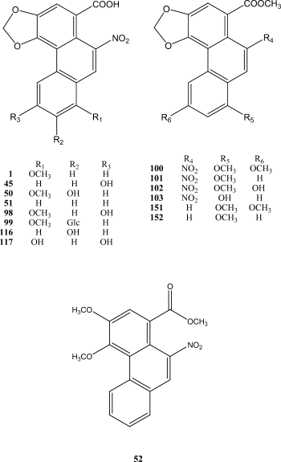

1. [Download : Download full-size image](https://ars.els-cdn.com/content/image/1-s2.0-S2225411016301110-gr1.gif)

Figure 1. [Aristolochic acids](https://www.sciencedirect.com/topics/medicine-and-dentistry/aristolochic-acid) and esters from the *Aristolochia* species.

### Aristolactams

Aristolactams are regarded as biogenetic intermediates in the biosynthetic pathway of aristolochic acids. They are usually supposed to originate from the cyclization condensation reaction of the reduction products of aristolochic acids. From Figure 2, it is evident that twelve aristolactams have been reported from *Aristolochia* species and among them there were also six compounds having the 3,4-methylenedioxy substitution groups. Aristolactam I (15), aristolactam AII (36), and aristolactam Ia *N*-β-D-glucoside (122) were the frequently encountered aristolactams in the *Aristolochia* species. Aristolactam II (36) found in several species of *Aristolochia* is a simple aristolactam without any substitutions on rings B and C. The 9-oxygenated aristolactams are rare in *Aristolochia* with only compounds 68 and 125 being reported. Compound 125 was one example of 9-oxygenated aristolactam with the substitution of diglucoside.

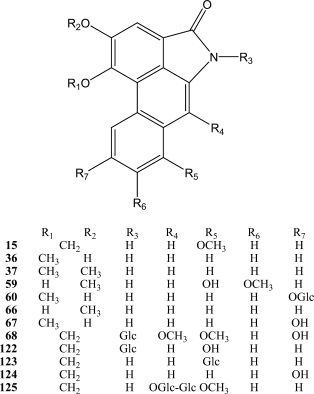

1. [Download : Download full-size image](https://ars.els-cdn.com/content/image/1-s2.0-S2225411016301110-gr2.gif)

Figure 2. [Aristolactams](https://www.sciencedirect.com/topics/medicine-and-dentistry/aristololactam) from the *Aristolochia* species.

### Aporphines

Seventeen aporphine [alkaloids](https://www.sciencedirect.com/topics/medicine-and-dentistry/alkaloid) have been characterzied from *Aristolochia* species (Figure 3). Aporphines with *N*-formyl substitution, 6 α, 7-dehydro-*N*-formylnornantenine (11) and *N*-formylnornantenine (12), were reported from *A. brevipes* (Navarro-García et al, 2011). The polar quaternary aporphine magnoflorine (104) was found in *A. elegans* and *A. gigantea*. The 4,5-dioxoaporphine is a small group of aporphine alkaloid found mostly among the *Aristolochia* ceae family and usually considered as possible intermediates of the precursors of aristolactams and aristolochic acids in plants. Only 4,5-dioxodehydro-asimilobine (107) was reported from *A. elegans* (Shi et al, 2004). Most of the aporphines found in *Aristolochia* species possess 4,5-tetrahydro basic skeleton. Lagesianines B-D (140-142) were the dimeric aporphine alkaloids linked through the substituent on nitrogen, oxygenated functions, and substituent on the phenanthrene ring, respectively. These dimeric aporphines were only reported from the leaves of *A. ligesiana* (Ferreira et al, 2010).

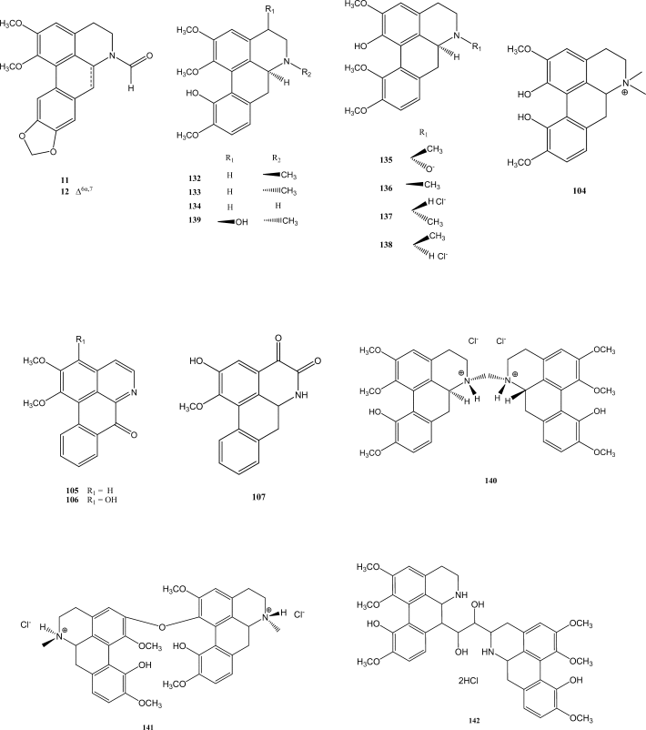

1. [Download : Download full-size image](https://ars.els-cdn.com/content/image/1-s2.0-S2225411016301110-gr3.gif)

Figure 3. [Aporphines](https://www.sciencedirect.com/topics/medicine-and-dentistry/aporphine-derivative) from the *Aristolochia* species.

### Protoberberines

Occurrence of protoberberine alkaloids (Figure 4) was rare in *Aristolochia*, and they were only reported from *A. constricta* (Capasso et al, 2006). 8-Benzyltetrahydroprotoberberine type alkaloid, 23, had been obtained by introduction of a benzyl group at C-8 of berberine to result in this unusual carbon skeleton.

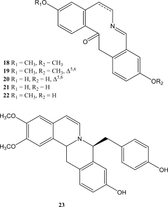

1. [Download : Download full-size image](https://ars.els-cdn.com/content/image/1-s2.0-S2225411016301110-gr4.gif)

Figure 4. Protoberberines from the *Aristolochia* species.

### Isoquinolines

The presence of [isoquinoline alkaloids](https://www.sciencedirect.com/topics/medicine-and-dentistry/isoquinoline-alkaloid) 78-82 in the genus *Aristolochia* is limited to *A. elegans*. Purified compounds of this class were listed in the Figure 5. All of these alkaloids reported possessed the tetrahydroisoquinolone basic skeleton. Isoquinoline alkaloids were usually considered as biogenetic intermediates in the catabolic process of bisbenzyl-tetrahydroisoquinoline alkaloids (Shi et al, 2004).

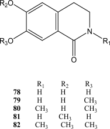

1. [Download : Download full-size image](https://ars.els-cdn.com/content/image/1-s2.0-S2225411016301110-gr5.gif)

Figure 5. [Isoquinolines](https://www.sciencedirect.com/topics/medicine-and-dentistry/isoquinoline-derivative) from the *Aristolochia* species.

### Benzylisoquinolines

The occurrence of benzylisoquinoline type alkaloids, aristoquinolines A-C (61-63) constitute the first report of *N*-oxide benzoyl benzyltetrahydroisoquinoline ether alkaloids from *Aristolochia* species (Figure 6). These provided the natural evidence for the catabolic process of structurally interesting bisbenzyltetrahydroisoquinol ines. The isoquinolones, benzylisoquinolines, biphenyl ethers, and *N*-oxide benzoyl benzyltetrahydroisoqu inoline ether alkaloids were derived biogenetically from bisbenzylisoquinolines, common metabolites of *Aristolochia* species, in general alkaloid catabolic process (Shi et al, 2004).

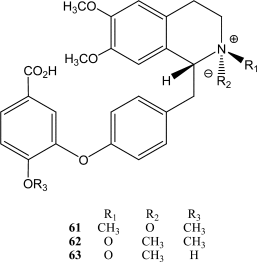

1. [Download : Download full-size image](https://ars.els-cdn.com/content/image/1-s2.0-S2225411016301110-gr6.gif)

Figure 6. [Benzylisoquinolines](https://www.sciencedirect.com/topics/medicine-and-dentistry/benzylisoquinoline-derivative) from the *Aristolochia* species.

### Amides

The amides are another type of compounds isolated from several *Aristolochia* plants (Figure 7). One class of the amides from *Aristolochia* species, on structural investigation were found to contain a tyramine unit connected to phenolic acids like *cis*- or *trans*- coumaric and ferulic acids. Aristolamide (149) and aristolamide II (150) isolated from *A. manshuriensis* (Chung et al, 2011) contain ─CONH<sub>2</sub> group at C-1 which possessed the phenanthrene basic skeleton was another class of amide reported from *Aristolochia* species.

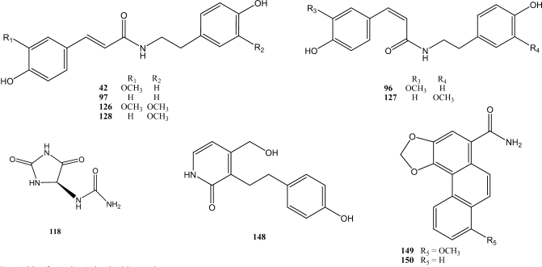

1. [Download : Download full-size image](https://ars.els-cdn.com/content/image/1-s2.0-S2225411016301110-gr7.gif)

Figure 7. [Amides](https://www.sciencedirect.com/topics/medicine-and-dentistry/carboxamide) from the *Aristolochia* species.

### Flavonoids

Flavonoids continue to attract the researchers’ interests due to their structural diversity, biological and ecological significance. They affect plant interactions with microsymbionts (Romeo et al, 1998), insect predators and pollinators (Harborne, 1986, Stafford, 1997), and also function in pigmentation and act as protectants against UV irradiation (Brouillard, 1988, Ylstra et al., 1992, Harborne, 1994). Virtually almost all higher plants produce flavonoids, however, some of them are fairly unique, in which many specific compounds are accumulated during plant [growth and development](https://www.sciencedirect.com/topics/medicine-and-dentistry/growth-development-and-aging). Six bisflavones, one unusual chalcone-flavone dimer and two [tetramers](https://www.sciencedirect.com/topics/medicine-and-dentistry/tetramer) were characterized from *A. ridicula* (Machado and Lopes, 2005, Machado and Lopes, 2008) (Figure 8). These reports constitute the presence of bi-and tetraflavonoids in the family *Aristolochia*ceae. In addition, there was also simple flavone reported from *Aristolochia* species, like kaempferol (161) from *A. tagala* (Battu et al, 2011).

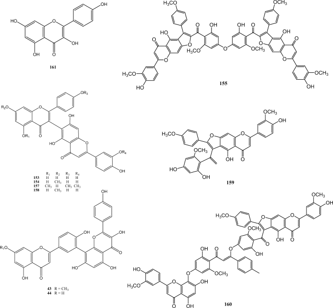

1. [Download : Download full-size image](https://ars.els-cdn.com/content/image/1-s2.0-S2225411016301110-gr8.gif)

Figure 8. [Flavonoids](https://www.sciencedirect.com/topics/medicine-and-dentistry/flavonoid) from the *Aristolochia* species.

### Lignans

Lignans were another important type of metabolites found in several species of *Aristolochia*. There are five basic skeletons of [neolignans](https://www.sciencedirect.com/topics/medicine-and-dentistry/neolignan) and lignans with structural diversity reported from *Aristolochia* genus (Figure 9), including diaryldimethyltetrahydrofuranoids, dibenzylbutanoids, [benzofurans](https://www.sciencedirect.com/topics/medicine-and-dentistry/benzofuran-derivative), and bisepoxylignans. The 2,5-diaryl-3,4-dimethyl-tetrahydrofuranoids 3-9 were all characterized from the roots of *A. arcuata* (Zhai et al., 2004, Zhai et al., 2005). Occurrence of the dibenzylbutane type lignans is the most common in *Aristolochia* genus. These lignans could be further divided into dibenzyltetrahydrofurans, dibenzylbutyrolactones, and dibenzylbutane diol depending on their oxidation states. Licarin A (162), licarin B (163), and eupomatenoid-7 (164) were benzofuran type lignans only reported from A. taliscana (León-Díaz et al, 2010). The other type of lignans frequently encountered in *Aristolochia* species were the bisepoxylignans which were exemplified in Figure 9, reported from *A. cymbifera*, *A. elegans, A. gigantea*, and *A. malmeana*, respectively. In addition, there was also one dimeric lignan (8*R*, 8’*R*, 8”*R*, 8’”*R*, 9*R*, 9”s)-bicubebin A (131) linked through the oxygen atom (de Pascoli et al, 2006).

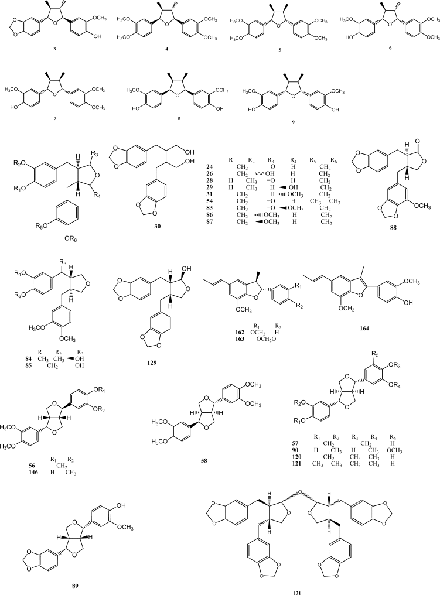

1. [Download : Download full-size image](https://ars.els-cdn.com/content/image/1-s2.0-S2225411016301110-gr9.gif)

Figure 9. [Lignans](https://www.sciencedirect.com/topics/medicine-and-dentistry/lignan) from the *Aristolochia* species.

### Biphenyl ethers

Seven biphenyl ethers had been reported, including aristogins A-E (69-73), F (64), and 4-methoxy-3,4-oxydibenzoic acid (74) (Figure 10). All these compounds have only been reported from *A. elegans* (Shi et al, 2004) and they are usually considered as one of the end products in the catabolic process of [bisbenzylisoquinoline alkaloids](https://www.sciencedirect.com/topics/medicine-and-dentistry/bisbenzylisoquinoline-alkaloid).

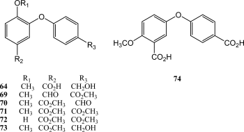

1. [Download : Download full-size image](https://ars.els-cdn.com/content/image/1-s2.0-S2225411016301110-gr10.gif)

Figure 10. [Biphenyl](https://www.sciencedirect.com/topics/medicine-and-dentistry/biphenyl) ethers from the *Aristolochia* species.

### Coumarins

Although there were only two coumarins, 7,9-dimeth oxytariacuripyrone (13) and 9 methoxytariacuripyrone (14), characterized from the roots of *A. brevipes* (Figure 11), these constituents also displayed significant physiological activity (Navarro-García et al, 2011).

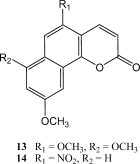

1. [Download : Download full-size image](https://ars.els-cdn.com/content/image/1-s2.0-S2225411016301110-gr11.gif)

Figure 11. [Coumarins](https://www.sciencedirect.com/topics/medicine-and-dentistry/coumarin-derivative) from the *Aristolochia* species.

### Tetralones

Among five tetralones reported from *Aristolochia* species so far (Figure 12), four tetralones, aristelegones A-D (38, 75-77) have been characterized in the stems and roots of *A. elegans* collected in Taiwan (Shi et al, 2004). Aristelegone A (38) and (+)-4,7-dimethyl-6-methoxy-1-tetralone (39) were reported from the stems of *A. constricta* (Zhang et al, 2008). Most of these identified tetralones possessed a keto substituent at C-1 except that aristelegone D (77) had 1,2-diol functionalities.

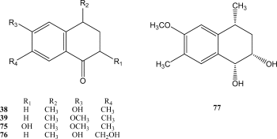

1. [Download : Download full-size image](https://ars.els-cdn.com/content/image/1-s2.0-S2225411016301110-gr12.gif)

Figure 12. [Tetralones](https://www.sciencedirect.com/topics/medicine-and-dentistry/tetralin-derivative) from the *Aristolochia* species.

### Terpenoids

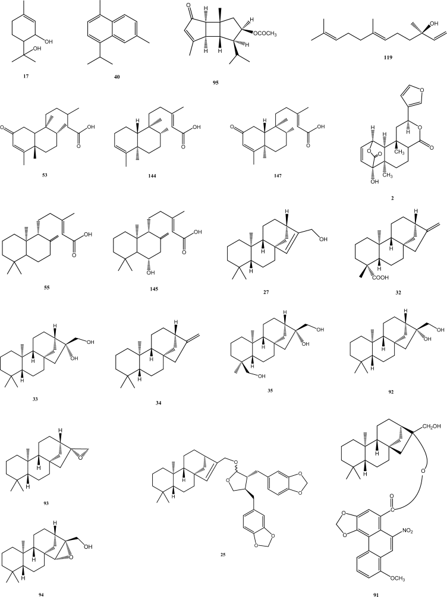

1. [Download : Download full-size image](https://ars.els-cdn.com/content/image/1-s2.0-S2225411016301110-gr13.gif)

Figure 13. [Terpenoids](https://www.sciencedirect.com/topics/medicine-and-dentistry/terpenoid) from the *Aristolochia* species.

### Benzenoids

A number of benzenoid derivatives were isolated from different *Aristolochia* species, which include phenylmethanoids and phenylpropanoids (Figure 14). Four simple benzenoid derivatives 108-111 were isolated from the stems and roots of *A. elegans* (Shi et al, 2004). Eight phenylpropanoids, including [aglycones](https://www.sciencedirect.com/topics/medicine-and-dentistry/aglycone) 112-115 from *A. elegans* and [glycosides](https://www.sciencedirect.com/topics/medicine-and-dentistry/glycoside) 46-49 from *A. cretica*, respectively, were reported and most of them are ferulic, cinnamic, p-coumaric, and caffeic acids derivatives.

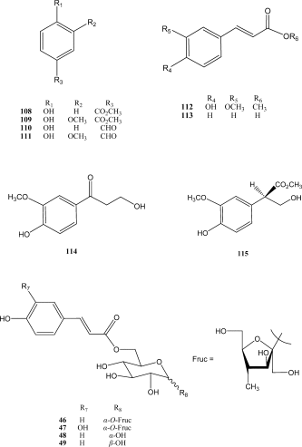

1. [Download : Download full-size image](https://ars.els-cdn.com/content/image/1-s2.0-S2225411016301110-gr14.gif)

Figure 14. [Benzenoids](https://www.sciencedirect.com/topics/medicine-and-dentistry/aromatic-compound) from the *Aristolochia* species.

### Steroids and others

Steroids are usually encountered in natural sources, and those presented in *Aristolochia* species are mostly derivatives of β-sitosterol and stigmasterol. Among these steroids, β-sitosterol (10) and β-sitosteryl glucoside (41) were frequently found in several *Aristolochia* species (Figure 15). In addition, some miscellaneous compounds including glycerol (143) and proto-quercitol (156) were also reported from *Aristolochia* species.

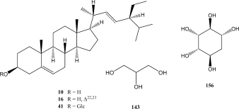

1. [Download : Download full-size image](https://ars.els-cdn.com/content/image/1-s2.0-S2225411016301110-gr15.gif)

Figure 15. Steroids and others from the *Aristolochia* species.

## Pharmacology

There were a lot of worthy achievements related to the pharmacology of *Aristolochia* to be published to evidence the extensive use of *Aristolochia* species in folk/traditional medicines. The aristolochic acids have been considered to be the most potent fraction of the *Aristolochia* constituents. Aristolochic acid I, the most active constituent of *Aristolochia* has been used for medicinal purposes since the Graeco-Roman period. However, following the observations that the compound was mutagenic and carcinogenic, it was removed from pharmaceutical products since a decade (Pharmacopoeia of the People's Republic of China, 1977). Various bioactivity studies have been reported to assess the traditional uses of *Aristolochia* species and these results were summarized in Table 2. Some of the *Aristolochia* species, including *A. baetica, A. bracteolata, A. indica, A. malmeana*, and *A. pubescens*, have been reported to exhibit insecticidal and repellent activities. The crude extracts of *A. brevipes, A. cymbifrea, A. indica, A. mollissima*, and *A. taliscana* also display significant [antimicrobial activities](https://www.sciencedirect.com/topics/medicine-and-dentistry/antimicrobial-activity). The phytochemical compositions and pharmacology of *Aristolochia* genus have evoked a great deal of interest due to their multiple traditional uses and various bioactivity reports on their crude extracts. Therefore, *Aristolochia* become one of the intensely investigated genera and a large number of papers have been published on the production of physiologically important metabolites by *Aristolochia*.

Table 2. Bioactivity of the crude extracts of the *Aristolochia* (馬兜鈴 mă dōu ling) species.

| Source | Parts | Bioactivity | Reference |
| --- | --- | --- | --- |
| *A. baetica* | stem | insecticidal | Jbilou et al, 2008 |
|  | roots | antiproliferative | Chaouki et al, 2010 |
| *A. bracteolata* | whole plant | antiplasmodial antiallergic | Ahmed et al, 2010 |
|  |  |  | Chitme et al, 2010 |
|  | leaves | antifeedant | Elango et al, 2011 |
| *A. brevipes* | ground roots | antimycobacterial | Navarro-García et al, 2011 |
| *A. constricta* | stems | antispasmodic | Zhang et al, 2008 |
| *A. cymbifrea* | whole plant | antimicrobial | de Barros Machado et al, 2005 |
|  | stems | antibacterial | Alviano et al, 2008 |
| *A. elegans* | roots and aerial part | anti scorpion venom | Izquierdo et al, 2010 |
|  | roots | anti scorpion venom | Jiménez-Ferrer et al, 2005 |
| *A. indica* | roots | antibacterial | Kumar et al, 2006 |
|  |  | antifungal | Kumar et al, 2006 |
|  | leaves | anti snake venom | Samy et al, 2008 |
|  | leaves | mosquito-adulticidal | Kamaraj et al, 2010 |
|  |  | mosquito-repellent | Kamaraj et al, 2010 |
|  |  | mosquito-larvicidal | Kamaraj et al, 2010 |
| *A. malmeana* | roots | insecticidal | Messiano et al, 2008 |
| *A. mollissima* | rhizome and aerial part | antimicrobial | Yu et al, 2007 |
| *A. pubescens* | roots and stems | insecticidal | Nascimento et al, 2003 |
| *A. tagala (syn: A. acuminata)* | roots | antiinflammatory | Battu et al, 2011 |
| *A. taliscana* | roots | antimycobacterial | León-Díaz et al, 2010 |

Table 3. Bioactivity of the compounds identified from the *Aristolochia* (馬兜鈴 smă dōu ling) species.

[output not shown]

Licarin A (162), licarin B (163), and eupomatenoid-7 (164) reported from *A. taliscana* (León-Díaz et al, 2010); and 7,9-dimethoxytariacuripyrone (13), 9-methoxytariacuripyrone (14), and aristololactam I (15) from *A. brevipes* (Navarro-García et al, 2011) were examined for their [antimycobacterial](https://www.sciencedirect.com/topics/medicine-and-dentistry/antimycobacterial-agent) effects and the results confirmed their potentials indicated in the crude extracts. *[Mycobacterium tuberculosis](https://www.sciencedirect.com/topics/medicine-and-dentistry/mycobacterium-tuberculosis)* (MTB) is one of the species of the so-called tuberculosis complex and is the causative agent of tuberculosis (TB). The increase in the number of cases of TB has been associated with the infection of humans with HIV, in addition to the appearance and development of TB-resistant drugs, both multidrug-resistant (MDR), as well as extremely drug-resistant (XDR). These studies demonstrated that the dichloromethane extracts of rhizomes of *A. brevipes* and hexane extracts of *A. taliscana* possesses strong *in vitro* antimycobacterial activity against *Mycobacterium tuberculosis* strains. Among the tested compounds, licarin A (162) was the most active compound, with minimum inhibitory concentrations (MICs) of 3.12-12.5 μg/mL against the following *M. tuberculosis* strains: H37Rv, four mono-resistant H37Rv variants and 12 clinical MDR isolates, as well as against five non-tuberculous mycobacteria (NTM) strains.

[Chagas disease](https://www.sciencedirect.com/topics/medicine-and-dentistry/chagas-disease) is a chronic illness caused by the flagellate protozoan *[Trypanosoma cruzi](https://www.sciencedirect.com/topics/medicine-and-dentistry/trypanosoma-cruzi)*, and it is the major cause of morbidity and mortality in many regions of South America. *A. cymbifera* has been used in traditional medicine as an abortifacient and an emmenagogue as well as in the treatment of fever, diarrhea, and eczema. The experimental results of purification of *A. cymbifera* and bioactivity study demonstrated that (−)-kusunokinin (54) and (−)-copalic acid (55) were the most active compounds against trypomastigotes of *T. cruzi*. Additionally, (−)-copalic acid (55) demonstrated the highest parasite selectivity as a result of low toxicity to [mammalian cells](https://www.sciencedirect.com/topics/medicine-and-dentistry/mammalian-cell), despite a considerable [hemolytic activity](https://www.sciencedirect.com/topics/medicine-and-dentistry/hemolysis) at higher concentrations. Among the isolated compounds, (−)-kusunokinin (54) could be considered the most promising candidate, as it displayed significant activity against intracellular amastigotes and trypomastigotes without hemolytic activity (Sartorelli et al, 2010).

## Nephrotoxicity

[Chinese herbs](https://www.sciencedirect.com/topics/medicine-and-dentistry/chinese-herbs) nephropathy (CHN) is a rapidly progressive [interstitial nephropathy](https://www.sciencedirect.com/topics/medicine-and-dentistry/interstitial-nephritis) reported after the introduction of Chinese herbs in a slimming regimen followed by young Belgian women (Vanherweghem et al., 1993, Nortier et al., 2000). Because of manufacturing error, there were several reports on the adverse effects of this slimming regimen. Firstly, in 1992, some cases of women presenting with a rapidly progressive renal failure after having followed a slimming regimen including powdered extracts of Chinese herbs, one of them being *Stephania tetrandra* were recorded. This outbreak of renal failure eventually resulted in about 100 cases in 1998, 70 % of them being in end-stage renal disease (ESRD) (Vanherweghem, 2002). Chinese herbs nephropathy is characterized by early, severe anemia, mild tubular proteinuria and initially normal [arterial blood pressure](https://www.sciencedirect.com/topics/medicine-and-dentistry/arterial-pressure) in half of the patients (Cosyns, 2003). The recent studies have confirmed that the main culprit leading to renal injury is aristolochic acid found in many Chinese [herbal preparations](https://www.sciencedirect.com/topics/medicine-and-dentistry/herbaceous-agent) (Balachandran et al., 2005, Nedelko et al., 2009, Chen et al., 2010b, Zhu et al., 2010, Chen et al., 2012). Aristolochic acid, a potent human carcinogen produced by *Aristolochia* plants, is associated with [urothelial carcinoma](https://www.sciencedirect.com/topics/medicine-and-dentistry/transitional-cell-carcinoma) of the [upper urinary tract](https://www.sciencedirect.com/topics/medicine-and-dentistry/upper-urinary-tract) (UUC). Following [metabolic activation](https://www.sciencedirect.com/topics/medicine-and-dentistry/metabolic-activation), aristolochic acid reacts with DNA to form aristolactam (AL)-DNA adducts. These lesions concentrate in the renal cortex, where they serve as a sensitive and specific biomarker of exposure, and are found also in the urothelium, where they give rise to a unique mutational signature in the TP53 tumor-suppressor gene. From the research results, it could be concluded that exposure to aristolochic acid contributed significantly to the incidence of UUC, a finding with significant implications for global public health (Chen et al, 2012).

## Conclusion

This review of literature including phytochemical and pharmacological investigations on *Aristolochia* species have covered 164 compounds belonged to the classes of aristolochic acids and esters, aristolactams, aporphines, protoberberines, isoquinolines, benzylisoquinolines, amides, flavonoids, lignans, biphenyl ethers, coumarins, tetralones, terpenoids, benzenoids, steroids, and others with extensive physiological activities. Recently, the focus of the pharmacology of the *Aristolochia* species was mainly on the nephrotoxic aristolochic acids responsible for a tragic disease of Chinese herb nephropathy recognized in 1992. It may thus be of more than academic interest to examine the remaining *Aristolochia* plants for their aristolochic acid presence to prevent the issues like Chinese herb nephropathy and Balkan endemic nephropathy. This review will help researchers and scientists in locating the detailed information on *Aristolochia* species and address the continuous development in the phytochemistry and the therapeutic application of the *Aristolochia* species in the period between 2004 and 2011.

## Acknowledgement

Authors are grateful for the financial support of the grants from the National Science Council, Taiwan, Republic of China.

## REFERENCES

**Ahmed et al., 2010**

E.H.M. Ahmed, B.Y.M. Nour, Y.G. Mohammed, H.S. Khalid

Antiplasmodial activity of some medicinal plants used in Sudanese folk-medicine

Environmental Health Insights, 4 (2010), pp. 1-6

Google Scholar

**Alviano et al., 2008**

W.S. Alviano, D.S. Alviano, C.G. Diniz, A.R. Antoniolli, C.S. Alviano, L.M. Farias, M.A.R. Carvalho, M.M.G. Souza, A.M. Bolognese

In vitro antioxidant potential of medicinal plant extracts and their activities against oral bacteria based on Brazilian folk medicine

Archives of Oral Biology, 53 (2008), pp. 545-552

[View PDF](https://www.sciencedirect.com/science/article/pii/S0003996907003160/pdfft?md5=3142f168317f398c63f4c58af7a503eb&pid=1-s2.0-S0003996907003160-main.pdf)[View article](https://www.sciencedirect.com/science/article/pii/S0003996907003160)[View in Scopus](https://www.scopus.com/inward/record.url?eid=2-s2.0-43049142584&partnerID=10&rel=R3.0.0)Google Scholar

**Andrei, 1977**

Andrei (Ed.), Farmacopeia homeopatica Brasileira, Sao Paulo (1977)

**Balachandran et al., 2005**

P. Balachandran, F. Wei, R.C. Lin, I.A. Khan, D.S. Pasco

Structure activity relationships of aristolochic acid analogues: toxicity in cultured renal epithelial cells

Kidney International, 67 (2005), pp. 1797-1805

[View PDF](https://www.sciencedirect.com/science/article/pii/S0085253815506571/pdfft?md5=3195bf4d357f218115782b8db08e2be8&pid=1-s2.0-S0085253815506571-main.pdf)[View article](https://www.sciencedirect.com/science/article/pii/S0085253815506571)[CrossRef](https://doi.org/10.1111/j.1523-1755.2005.00277.x)[View in Scopus](https://www.scopus.com/inward/record.url?eid=2-s2.0-17744363092&partnerID=10&rel=R3.0.0)Google Scholar

**Balbach, 1979**

A. Balbach

Flora nacional na medicina domestica (11th Ed), Edel, Sao Paulo (1979), p. 45

458, 573, 739, 840

[Google Scholar](https://scholar.google.com/scholar_lookup?title=Flora%20nacional%20na%20medicina%20domestica&publication_year=1979&author=A.%20Balbach)

**Battu et al., 2011**

G.R. Battu, R. Parimi, K.B.C. Shekar

*In vivo* and *in vitro* pharmacological activity of *Aristolochia tagala* (syn: *Aristolochia acuminate*) root extracts

Pharmaceutical Biology, 49 (2011), pp. 1210-1214

[CrossRef](https://doi.org/10.3109/13880209.2011.589855)[View in Scopus](https://www.scopus.com/inward/record.url?eid=2-s2.0-80054924023&partnerID=10&rel=R3.0.0)[Google Scholar](https://scholar.google.com/scholar?q=In%20vivo%20and%20in%20vitro%20pharmacological%20activity%20of%20Aristolochia%20tagala%20%20root%20extracts)

**Bensky et al., 1993**

D. Bensky, A. Gamble, T. Kaptchuk, L.L. Bensky

Chinese herbal medicine: materia medica (revised Ed.), Eastland Press, Seattle (1993), p. 136

[Google Scholar](https://scholar.google.com/scholar_lookup?title=Chinese%20herbal%20medicine%3A%20materia%20medica&publication_year=1993&author=D.%20Bensky&author=A.%20Gamble&author=T.%20Kaptchuk&author=L.L.%20Bensky)

**Brouillard, 1988**

R. Brouillard

The flavonoids – advances in research since 1980, Chapman and Hall, New York (1988), p. 525

[CrossRef](https://doi.org/10.1007/978-1-4899-2913-6_16)[View in Scopus](https://www.scopus.com/inward/record.url?eid=2-s2.0-84909995345&partnerID=10&rel=R3.0.0)[Google Scholar](https://scholar.google.com/scholar?q=The%20flavonoids%20%20advances%20in%20research%20since%201980)

**Cai and Cai, 2010**

Y. Cai, T.G. Cai

Two new aristolochic acid derivatives from the roots of *Aristolochia fangchi* and their cytotoxicities

Chemical and Pharmaceutical Bulletin, 58 (2010), pp. 1093-1095

[CrossRef](https://doi.org/10.1248/cpb.58.1093)[View in Scopus](https://www.scopus.com/inward/record.url?eid=2-s2.0-77955355101&partnerID=10&rel=R3.0.0)Google Scholar

**Capasso et al., 2006**

A. Capasso, S. Piacente, N.D. Tommasi, L. Rastrelli, C. Pizza

The effect of isoquinoline alkaloids on opiate withdrawal

Current Medicinal Chemistry, 13 (2006), pp. 807-812

[CrossRef](https://doi.org/10.2174/092986706776055616)[View in Scopus](https://www.scopus.com/inward/record.url?eid=2-s2.0-33645971335&partnerID=10&rel=R3.0.0)Google Scholar

**Chaouki et al., 2010**

W. Chaouki, D.Y. Leger, J. Eljastimi, J.L. Beneytout, M. Hmamouchi

Antiproliferative effect of extracts from *Aristolochia baetica* and *Origanum compactum* on human breast cancer cell line MCF–7

Pharmaceutical Biology, 48 (2010), pp. 269-274

[CrossRef](https://doi.org/10.3109/13880200903096588)[View in Scopus](https://www.scopus.com/inward/record.url?eid=2-s2.0-77249135810&partnerID=10&rel=R3.0.0)[Google Scholar](https://scholar.google.com/scholar?q=Antiproliferative%20effect%20of%20extracts%20from%20Aristolochia%20baetica%20and%20Origanum%20compactum%20on%20human%20breast%20cancer%20cell%20line%20MCF7)

**Chen et al., 2005**

Y.G. Chen, L.L. Yu, R. Huang, J.C. Liu, Y.P. Lv, Y. Zhao

3″-Hydoxyamentoflavone and its 7-*O*-methyl ether, tow new biflavonoids from *Aristolochia contorta*

Archives of Pharmacal Research, 28 (2005), pp. 1233-1235

[View in Scopus](https://www.scopus.com/inward/record.url?eid=2-s2.0-28844442345&partnerID=10&rel=R3.0.0)[Google Scholar](https://scholar.google.com/scholar?q=3-Hydoxyamentoflavone%20and%20its%207-O-methyl%20ether,%20tow%20new%20biflavonoids%20from%20Aristolochia%20contorta)

**Chen et al., 2010a**

Y.Y. Chen, S.Y. Chiang, H.C. Wu, S.T. Kao, C.Y. Hsiang, T.Y. Ho, J.G. Lin

Microarray analysis reveals the inhibition of nuclear factor-kappa B signaling by aristolochic acid in normal human kidney (HK-2) cells

Acta Pharmacologica Sinica, 31 (2010), pp. 227-236

[CrossRef](https://doi.org/10.1038/aps.2009.197)[View in Scopus](https://www.scopus.com/inward/record.url?eid=2-s2.0-76949108679&partnerID=10&rel=R3.0.0)[Google Scholar](https://scholar.google.com/scholar?q=Microarray%20analysis%20reveals%20the%20inhibition%20of%20nuclear%20factor-kappa%20B%20signaling%20by%20aristolochic%20acid%20in%20normal%20human%20kidney%20%20cells)

**Chen et al., 2010b**

Y.Y. Chen, J.G. Chung, H.C. Wu, D.T. Bau, K.Y. Wu, S.T. Kao, C.Y. Hsiang, T.Y. Ho, S.Y. Chiang

Aristolochic acid suppresses DNA repair and triggers oxidative DNA damage in human kidney proximal tubular cells

Oncology Reports, 24 (2010), pp. 141-153

[View in Scopus](https://www.scopus.com/inward/record.url?eid=2-s2.0-77952989674&partnerID=10&rel=R3.0.0)Google Scholar

**Chen et al., 2012**

C.H. Chen, K.G. Dickman, M. Moriya, J. Zavadil, V.S. Sidorenko, K.L. Edwards, D.V. Gnatenko, L. Wu, R.J. Turesky, X.R. Wu, Y.S. Pu, A.P. Grollman

Aristolochic acid-associated urothelial cancer in Taiwan

Proceedings of the National Academy of Sciences of the United States of America, 109 (2012), pp. 8241-8246

[CrossRef](https://doi.org/10.1073/pnas.1119920109)[View in Scopus](https://www.scopus.com/inward/record.url?eid=2-s2.0-84861428636&partnerID=10&rel=R3.0.0)Google Scholar

**Chitme et al., 2010**

H.R. Chitme, M. Malipatil, V.M. Chandrashekhar, P.M. Prashant

Antiallergic activity of *Aristolochia* bracteolate Lank in animal model

Indian Journal of Experimental Biology, 48 (2010), pp. 46-52

[View in Scopus](https://www.scopus.com/inward/record.url?eid=2-s2.0-77951930157&partnerID=10&rel=R3.0.0)Google Scholar

**Chung et al., 2011**

Y.M. Chung, F.R. Chang, T.F. Tseng, T.L. Hwang, L.C. Chen, S.F. Wu, C.L. Lee, Z.Y. Lin, L.Y. Chuang, J.H. Su, Y.C. Wu

A novel alkaloid, aristopyridinone A and anti-inflammatory phenanthrenes isolated from *Aristolochia manshuriensis*

Bioorganic & Medicinal Chemistry Letters, 21 (2011), pp. 1792-1794

[View PDF](https://www.sciencedirect.com/science/article/pii/S0960894X11000904/pdfft?md5=f02cd4489c897434c1155b49bc429701&pid=1-s2.0-S0960894X11000904-main.pdf)[View article](https://www.sciencedirect.com/science/article/pii/S0960894X11000904)[View in Scopus](https://www.scopus.com/inward/record.url?eid=2-s2.0-79952360536&partnerID=10&rel=R3.0.0)Google Scholar

**Correa, 1978**

M.P. Correa

Dicionario das plantas uteis do Brasil e das exoticas cultivadas, 1-2, Imprensa Nacional, Rio de Janeiro (1978), pp. 1926-1978

**Cosyns, 2003**

J.P. Cosyns

Aristolochic acid and ‘Chinese herbs nephropathy′: a review of the evidence to date

Drug Safety, 26 (2003), pp. 33-48

[CrossRef](https://doi.org/10.2165/00002018-200326010-00004)[View in Scopus](https://www.scopus.com/inward/record.url?eid=2-s2.0-0037229943&partnerID=10&rel=R3.0.0)[Google Scholar](https://scholar.google.com/scholar?q=Aristolochic%20acid%20and%20Chinese%20herbs%20nephropathy:%20a%20review%20of%20the%20evidence%20to%20date)

**de Barros Machado et al., 2005**

T. de Barros Machado, I.C.R. Leal, R.M. Kuster, A.C.F. Amaral, V. Kokis, M.G. de Silva, K.R.N. dos Santos

Brazilian phytopharmaceuticals – evaluation against hospital bacteria

Phytotherapy Research, 19 (2005), pp. 519-525

[CrossRef](https://doi.org/10.1002/ptr.1696)[Google Scholar](https://scholar.google.com/scholar?q=Brazilian%20phytopharmaceuticals%20%20evaluation%20against%20hospital%20bacteria)

**de Pascoli et al., 2006**

I.C. de Pascoli, I.R. Nascimento, L.M.X. Lopes

Configurational analysis of cubebins and bicubebin from *Aristolochia lagesiana* and *Aristolochia pubescens*

Phytochemistry, 67 (2006), pp. 735-742

[View PDF](https://www.sciencedirect.com/science/article/pii/S0031942206000409/pdfft?md5=1d539218fcc42a44bbce170b4dccc04d&pid=1-s2.0-S0031942206000409-main.pdf)[View article](https://www.sciencedirect.com/science/article/pii/S0031942206000409)[View in Scopus](https://www.scopus.com/inward/record.url?eid=2-s2.0-33645103360&partnerID=10&rel=R3.0.0)Google Scholar

**Duke, 1985**

J.A. Duke

CRC handbook of medicinal herbs, CRC Press, Boca Raton, FL (1985), p. 63

[Google Scholar](https://scholar.google.com/scholar_lookup?title=CRC%20handbook%20of%20medicinal%20herbs&publication_year=1985&author=J.A.%20Duke)

**Duke and Ayensu, 1985**

J.A. Duke, E.S. Ayensu

Medicinal plants of China, 1, Reference Publications Inc, Algonac, MI (1985), p. 131

**Elango et al., 2011**

G. Elango, A.A. Rahuman, C. Kamaraj, A. Bagavan, A.A. Zahir

Screening for feeding deterrent activity of herbal extracts against the larvae of malaria vector *Anopheles subpictus* Grassi

Parasitology Research, 109 (2011), pp. 715-726

[CrossRef](https://doi.org/10.1007/s00436-011-2306-7)[View in Scopus](https://www.scopus.com/inward/record.url?eid=2-s2.0-80052316465&partnerID=10&rel=R3.0.0)Google Scholar

**Ferreira et al., 2010**

M.L.R. Ferreira, I.C. de Pascoli, I.R. Nascimento, J. Zukerman-Schpector, L.M.X. Lopes

Aporphine and bisaporphine alkaloids from *Aristolochia lagesiana* var. *intermedia*

Phytochemistry, 71 (2010), pp. 469-478

[View PDF](https://www.sciencedirect.com/science/article/pii/S0031942209005305/pdfft?md5=c479166f4698b78d6bcb88adcf0d977c&pid=1-s2.0-S0031942209005305-main.pdf)[View article](https://www.sciencedirect.com/science/article/pii/S0031942209005305)[View in Scopus](https://www.scopus.com/inward/record.url?eid=2-s2.0-76249122545&partnerID=10&rel=R3.0.0)Google Scholar

**Georgopoulou et al., 2005**

C. Georgopoulou, N. Aligiannis, N. Fokialakis, S. Mitaku

Acretoside, a new sucrose ester from *Aristolochia cretica*

Journal of Asian Natural Products Research, 7 (2005), pp. 799-803

[CrossRef](https://doi.org/10.1080/1028602042000191617)[View in Scopus](https://www.scopus.com/inward/record.url?eid=2-s2.0-28944437230&partnerID=10&rel=R3.0.0)Google Scholar

**Gonzalez, 1999**

F. Gonzalez

A phylogenetic analysis of the Aristolochioideae (*Aristolochia* ceae), The City University of New York (1999)

Ph. D thesis

[Google Scholar](https://scholar.google.com/scholar?q=A%20phylogenetic%20analysis%20of%20the%20Aristolochioideae)

**Harborne, 1986**

J.B. Harborne

Plant flavonoids in biology and medicine: biochemical, pharmacological, and structure-activity relationships

V. Cody, E. Middleton Jr., J.B. Harborne (Eds.), Progress in clinical and biological research, Alan R. Liss, New York (1986), p. 15

Google Scholar

**Harborne, 1994**

J.B. Harborne

The flavonoids – advances in research since 1986, Chapman and Hall, London (1994)

[Google Scholar](https://scholar.google.com/scholar?q=The%20flavonoids%20%20advances%20in%20research%20since%201986)

**Hegde et al., 2010**

V.R. Hegde, S. Borges, M. Patel, P.R. Das, B. Wu, V.P. Gullo, T.M. Chan

New potential antitumor compounds from the plant *Aristolochia manshuriensis* as inhibitors of the CDK2 enzyme

Bioorganic & Medicinal Chemistry Letters, 20 (2010), pp. 1344-1346

[View PDF](https://www.sciencedirect.com/science/article/pii/S0960894X1000020X/pdfft?md5=de402b8eb3ab18b66cd25f3b33e8fde3&pid=1-s2.0-S0960894X1000020X-main.pdf)[View article](https://www.sciencedirect.com/science/article/pii/S0960894X1000020X)[View in Scopus](https://www.scopus.com/inward/record.url?eid=2-s2.0-75449096843&partnerID=10&rel=R3.0.0)Google Scholar

**Holzbach and Lopes, 2010**

J.C. Holzbach, L.M.X. Lopes

Aristolactams and alkamides of *Aristolochia gigantea*

Molecules, 15 (2010), pp. 9462-9472

[CrossRef](https://doi.org/10.3390/molecules15129462)[View in Scopus](https://www.scopus.com/inward/record.url?eid=2-s2.0-78650636272&partnerID=10&rel=R3.0.0)[Google Scholar](https://scholar.google.com/scholar_lookup?title=Aristolactams%20and%20alkamides%20of%20Aristolochia%20gigantea&publication_year=2010&author=J.C.%20Holzbach&author=L.M.X.%20Lopes)

**Hou, 1996**

D. Hou

(2nd Ed), Flora of Taiwan, 2, Editorial Committee of the Flora of Taiwan, Taipei (1996), pp. 636-642

[View in Scopus](https://www.scopus.com/inward/record.url?eid=2-s2.0-0345197978&partnerID=10&rel=R3.0.0)

**How, 1985**

F.C. How

A dictionary of the families and genera of Chinese seed plants (2nd Ed.), Science Press, Beijing (1985), p. 43

[Google Scholar](https://scholar.google.com/scholar_lookup?title=A%20dictionary%20of%20the%20families%20and%20genera%20of%20Chinese%20seed%20plants&publication_year=1985&author=F.C.%20How)

**Hutchinson, 1973**

J. Hutchinson

The families of flowering plants (3rd Ed.), Clarendon Press, Oxford (1973), p. 510

[Google Scholar](https://scholar.google.com/scholar_lookup?title=The%20families%20of%20flowering%20plants&publication_year=1973&author=J.%20Hutchinson)

**Izquierdo et al., 2010**

A.M. Izquierdo, E.V. Zapata, J.E. Jiménez-Ferrer, C.B. Muñoz, A.J. Aparicio, K.B. Torres, L.O. Torres

Scorpion antivenom effect of micropropagated *Aristolochia elegans*

Pharmaceutical Biology, 48 (2010), pp. 891-896

[CrossRef](https://doi.org/10.3109/13880200903311110)[View in Scopus](https://www.scopus.com/inward/record.url?eid=2-s2.0-77955187242&partnerID=10&rel=R3.0.0)Google Scholar

**Jbilou et al., 2008**

R. Jbilou, H. Amri, N. Bouayad, N. Ghailani, A. Ennabili, F. Sayah

Insecticidal effects of extracts of seven plant species on larval development, α-amylase activity and offspring production of *Tribolium castaneum* (Herbst) (Insecta: Coleoptera: Tenebrionidae)

Bioresource Technology, 99 (2008), pp. 959-964

[View PDF](https://www.sciencedirect.com/science/article/pii/S0960852407002477/pdfft?md5=8fa305e473f399e1003f78589c464f8b&pid=1-s2.0-S0960852407002477-main.pdf)[View article](https://www.sciencedirect.com/science/article/pii/S0960852407002477)[View in Scopus](https://www.scopus.com/inward/record.url?eid=2-s2.0-37049013905&partnerID=10&rel=R3.0.0)Google Scholar

**Jiangsu New Medicine College, 1977**

Jiangsu New Medicine College

Encyclopedia of Chinese materia medica, 1, Shanghai Science and Technology Press, Shanghai (1977), p. 294

**Jiménez-Ferrer et al., 2005**

J.E. Jiménez-Ferrer, Y.Y. Pérez-Terán, R. Román-Ramos, J. Tortoriello

Antitoxin activity of plants used in Mexican traditional medicine against scorpion poisoning

Phytomedicine, 12 (2005), pp. 116-122

[View PDF](https://www.sciencedirect.com/science/article/pii/S0944711304000911/pdfft?md5=c5d5bedfd20fda00e4008e44f637b3e8&pid=1-s2.0-S0944711304000911-main.pdf)[View article](https://www.sciencedirect.com/science/article/pii/S0944711304000911)[CrossRef](https://doi.org/10.1016/j.phymed.2003.10.001)[View in Scopus](https://www.scopus.com/inward/record.url?eid=2-s2.0-12944324734&partnerID=10&rel=R3.0.0)Google Scholar

**Kamaraj et al., 2010**

C. Kamaraj, A.A. Rahuman, A. Mahapatra, A. Bagavan, G. Elango

Insecticidal and larvicidal activities of medicinal plant extracts against mosquitoes

Parasitology Research, 107 (2010), pp. 1337-1349

[CrossRef](https://doi.org/10.1007/s00436-010-2006-8)[View in Scopus](https://www.scopus.com/inward/record.url?eid=2-s2.0-78449306021&partnerID=10&rel=R3.0.0)Google Scholar

**Kumar et al., 2006**

V.P. Kumar, N.S. Chauhan, H. Padh, M. Rajani

Search for antibacterial and antifungal agents from selected Indian medicinal plants

Journal of Ethnopharmacology, 107 (2006), pp. 182-188

[View PDF](https://www.sciencedirect.com/science/article/pii/S0378874106001346/pdfft?md5=1633b03b2d134c6b97aec093355ff751&pid=1-s2.0-S0378874106001346-main.pdf)[View article](https://www.sciencedirect.com/science/article/pii/S0378874106001346)[View in Scopus](https://www.scopus.com/inward/record.url?eid=2-s2.0-33747603674&partnerID=10&rel=R3.0.0)Google Scholar

**León-Díaz et al., 2010**

R. León-Díaz, M. Meckes, S. Said-Fernández, G.M. Molina-Salinas, J. Vargas-Villarreal, J. Torres, J. Luna-Herrera, A. Jiménez-Arellanes

Antimycobacterial neolignans isolated from *Aristolochia taliscana*

Memórias do Instituto Oswaldo Cruz, Rio de Janeiro, 105 (2010), pp. 45-51

[CrossRef](https://doi.org/10.1590/S0074-02762010000100006)[View in Scopus](https://www.scopus.com/inward/record.url?eid=2-s2.0-76749122909&partnerID=10&rel=R3.0.0)Google Scholar

**Li, 1977**

S.Z. Li

Ban Tso Gan Mo, Peoples Health Press, Beijing (1977), p. 1595

[Google Scholar](https://scholar.google.com/scholar_lookup?title=Ban%20Tso%20Gan%20Mo&publication_year=1977&author=S.Z.%20Li)

**Liu and Lai, 1976**

T.S. Liu, M.J. Lai

Flora of Taiwan, 2, Epoch, Taipei (1976), p. 572

**Lopes et al., 2001**

L.M.X. Lopes, I.R. Nascimento, T. Da Silva

Phytochemistry of the *Aristolochia*ceae family

R.M.M. Mohan (Ed.), Research advances in phytochemistry, 2, Global Research Network, Kerala (2001), pp. 19-108

[Google Scholar](https://scholar.google.com/scholar_lookup?title=Phytochemistry%20of%20the%20Aristolochiaceae%20family&publication_year=2001&author=L.M.X.%20Lopes&author=I.R.%20Nascimento&author=T.%20Da%20Silva)

**Machado and Lopes, 2005**

M.B. Machado, L.M.X. Lopes

Chalcone-flavone tetramer and biflavones from *Aristolochia ridicula*

Phytochemistry, 66 (2005), pp. 669-674

[View PDF](https://www.sciencedirect.com/science/article/pii/S0031942205000361/pdfft?md5=45884eae3a52a0e4868eb0a359d60f91&pid=1-s2.0-S0031942205000361-main.pdf)[View article](https://www.sciencedirect.com/science/article/pii/S0031942205000361)[View in Scopus](https://www.scopus.com/inward/record.url?eid=2-s2.0-14844344014&partnerID=10&rel=R3.0.0)[Google Scholar](https://scholar.google.com/scholar_lookup?title=Chalcone-flavone%20tetramer%20and%20biflavones%20from%20Aristolochia%20ridicula&publication_year=2005&author=M.B.%20Machado&author=L.M.X.%20Lopes)

**Machado and Lopes, 2008**

M.B. Machado, L.M.X. Lopes

Tetraflavonoid and biflavonoids from *Aristolochia ridicula*

Phytochemistry, 69 (2008), pp. 3095-3102

[View PDF](https://www.sciencedirect.com/science/article/pii/S0031942208002227/pdfft?md5=2dbc1842c2bcdc8b5a7b04a28fece716&pid=1-s2.0-S0031942208002227-main.pdf)[View article](https://www.sciencedirect.com/science/article/pii/S0031942208002227)[View in Scopus](https://www.scopus.com/inward/record.url?eid=2-s2.0-56949088402&partnerID=10&rel=R3.0.0)[Google Scholar](https://scholar.google.com/scholar_lookup?title=Tetraflavonoid%20and%20biflavonoids%20from%20Aristolochia%20ridicula&publication_year=2008&author=M.B.%20Machado&author=L.M.X.%20Lopes)

**Messiano et al., 2008**

G.B. Messiano, L. Vieira, M.B. Machado, L.M.X. Lopes, S.A. de Bortoli, J. Zukerman-Schpector

Evaluation of insecticidal activity of diterpenes and lignans from *Aristolochia malmeana* against *Anticarsia gemmatalis*

Journal of Agricultural and Food Chemistry, 56 (2008), pp. 2655-2659

[CrossRef](https://doi.org/10.1021/jf703594z)[View in Scopus](https://www.scopus.com/inward/record.url?eid=2-s2.0-43649092299&partnerID=10&rel=R3.0.0)Google Scholar

**Nascimento et al., 2003**

I.R. Nascimento, A.T. Murata, S.A. Bortoli, L.M.X. Lopes

Insecticidal activity of chemical constituents from *Aristolochia pubescens* against *Anticarsia gemmatalis* larvae

Pest Management Science, 60 (2003), pp. 413-416

Google Scholar

**Navarro-García et al., 2011**

V.M. Navarro-García, J. Luna-Herrera, M.G. Rojas-Bribiesca, P. Álvarez-Fitz, M.Y. Ríos

Antibacterial activity of *Aristolochia brevipes* against multidrug-resistant *Mycobacterium tuberculosis*

Molecules, 16 (2011), pp. 7357-7364

[CrossRef](https://doi.org/10.3390/molecules16097357)[View in Scopus](https://www.scopus.com/inward/record.url?eid=2-s2.0-80053262089&partnerID=10&rel=R3.0.0)Google Scholar

**Nedelko et al., 2009**

T. Nedelko, V.M. Arlt, D.H. Phillips, M. Hollstein

TP53 mutation signature supports involvement of aristolochic acid in the aetiology of endemic nephropathy-associated tumours

International Journal of Cancer, 124 (2009), pp. 987-990

[CrossRef](https://doi.org/10.1002/ijc.24006)[View in Scopus](https://www.scopus.com/inward/record.url?eid=2-s2.0-58149459327&partnerID=10&rel=R3.0.0)Google Scholar

**Nok et al., 2005**

A.J. Nok, B.A. Sallau, E. Onyike, N.M. Useh

Columbin inhibits cholesterol uptake in bloodstream forms of *Trypanosoma brucei* − A possible trypanocidal mechanism

Journal of Enzyme Inhibition and Medicinal Chemistry, 20 (2005), pp. 365-368

[CrossRef](https://doi.org/10.1080/14756360400028127)[View in Scopus](https://www.scopus.com/inward/record.url?eid=2-s2.0-24644480177&partnerID=10&rel=R3.0.0)[Google Scholar](https://scholar.google.com/scholar?q=Columbin%20inhibits%20cholesterol%20uptake%20in%20bloodstream%20forms%20of%20Trypanosoma%20bruceiA%20possible%20trypanocidal%20mechanism)

**Nortier et al., 2000**

J.L. Nortier, M.C.M. Martinez, H.H. Schmeiser, V.M. Arlt, C.A. Bieler, M. Petein, M.F. Depierreux, L.D. Pauw, D. Abramowicz, P. Vereerstraeten, J.L. Vanherweghem

Urothelial carcinoma associated with the use of a Chinese herb (*Aristolochia fangchi*)

The New England Journal of Medicine, 342 (2000), pp. 1686-1692

[View in Scopus](https://www.scopus.com/inward/record.url?eid=2-s2.0-0034622082&partnerID=10&rel=R3.0.0)[Google Scholar](https://scholar.google.com/scholar?q=Urothelial%20carcinoma%20associated%20with%20the%20use%20of%20a%20Chinese%20herb)

**Perry, 1980**

L.M. Perry

Medicinal plants of the East and Southeast Asia, MIT press, Cambridge (1980)

[Google Scholar](https://scholar.google.com/scholar_lookup?title=Medicinal%20plants%20of%20the%20East%20and%20Southeast%20Asia&publication_year=1980&author=L.M.%20Perry)

**Pharmacopoeia of the People’s Republic of China, 1977**

Pharmacopoeia of the People’s Republic of China

(English Edition), The Pharmacopeia Commission of PROC, Beijing (1977)

Pharmacopeia of China, 1, Peoples Press, Beijing (1985), pp. 36-38

**Romeo et al., 1998**

J. Romeo, K. Downum, R. Verpoorte

Recent advances in phytochemistry, Plenum Publication, New York (1998)

[Google Scholar](https://scholar.google.com/scholar_lookup?title=Recent%20advances%20in%20phytochemistry&publication_year=1998&author=J.%20Romeo&author=K.%20Downum&author=R.%20Verpoorte)

**Samy et al., 2008**

R.P. Samy, M.M. Thwin, P. Gopalakrishnakone, S. Ignacimuthu

Ethnobotanical survey of folk plants for the treatment of snakebites in Southern part of Tamilnadu, India

Journal of Ethnopharmacology, 115 (2008), pp. 302-312

[View PDF](https://www.sciencedirect.com/science/article/pii/S0378874107005314/pdfft?md5=c5e6f14528ab95f7122fac478453ac63&pid=1-s2.0-S0378874107005314-main.pdf)[View article](https://www.sciencedirect.com/science/article/pii/S0378874107005314)[View in Scopus](https://www.scopus.com/inward/record.url?eid=2-s2.0-37249088813&partnerID=10&rel=R3.0.0)Google Scholar

**Sartorelli et al., 2010**

P. Sartorelli, C.S. Carvalho, J.Q. Reimão, H. Lorenzi, A.G. Tempone

Antitrypanosomal activity of diterpene and lignans isolated from *Aristolochia cymbifera*

Planta Medica, 76 (2010), pp. 1454-1456

[CrossRef](https://doi.org/10.1055/s-0029-1240952)[View in Scopus](https://www.scopus.com/inward/record.url?eid=2-s2.0-77956676717&partnerID=10&rel=R3.0.0)Google Scholar

**Shen et al., 2008**

M.Y. Shen, C.L. Liu, G. Hsiao, C.Y. Liu, K.H. Lin, D.S. Chou, J.R. Sheu

Involvement of p38 MAPK phosphorylation and nitrate formation in aristolochic acid-mediated antiplatelet activity

Planta Medica, 74 (2008), pp. 1240-1245

[CrossRef](https://doi.org/10.1055/s-2008-1074560)[View in Scopus](https://www.scopus.com/inward/record.url?eid=2-s2.0-50649118645&partnerID=10&rel=R3.0.0)Google Scholar

**Shi et al., 2004**

L.S. Shi, P.C. Kuo, Y.L. Tsai, A.G. Damu, T.S. Wu

The alkaloids and other constituents from the root and stem of *Aristolochia elegans*

Bioorganic & Medicinal Chemistry, 12 (2004), pp. 439-446

[View PDF](https://www.sciencedirect.com/science/article/pii/S0968089603007181/pdfft?md5=fb0c4ef54f9d15bf6ba0d0d31f0546da&pid=1-s2.0-S0968089603007181-main.pdf)[View article](https://www.sciencedirect.com/science/article/pii/S0968089603007181)[View in Scopus](https://www.scopus.com/inward/record.url?eid=2-s2.0-0347951161&partnerID=10&rel=R3.0.0)Google Scholar

**Simoes et al., 1986**

C.M.O. Simoes, L.A. Mentz, E.P. Schenkel, B.E. Iragang, J.R. Stehmann

Plants da Medicina Popular no Rio Grande do Sul, UFRGS Ed, Porto Alegre (1986), p. 50

Google Scholar

**Stafford, 1997**

H.A. Stafford

Roles of flavonoids in symbiotic and defense functions in legume roots

The Botanical Review, 63 (1997), pp. 27-39

[View in Scopus](https://www.scopus.com/inward/record.url?eid=2-s2.0-0031459111&partnerID=10&rel=R3.0.0)[Google Scholar](https://scholar.google.com/scholar_lookup?title=Roles%20of%20flavonoids%20in%20symbiotic%20and%20defense%20functions%20in%20legume%20roots&publication_year=1997&author=H.A.%20Stafford)

**Tang and Eisenbrand, 1992**

W. Tang, G. Eisenbrand

Chinese drug of plant origin chemistry, pharmacology and use in traditional and modern medicine, Springer-Verlag, Berlin (1992), p. 145

[CrossRef](https://doi.org/10.1007/978-3-642-73739-8_21)Google Scholar

**The European Agency for the Evaluation of Medicinal Products, 1997**

The European Agency for the Evaluation of Medicinal Products

Veterinary Medicines Evaluation unit, London (1997)

**Therapuetic Goods Administration, 2001**

Therapuetic Goods Administration

Practitioner alert, Commonwealth department of Health and Aged care, Australia (2001)

[Google Scholar](https://scholar.google.com/scholar_lookup?title=Practitioner%20alert&publication_year=2001&author=Therapuetic%20Goods%20Administration)

**Vanherweghem et al., 1993**

J.L. Vanherweghem, M. Depierreux, C. Tielemans, D. Abramowicz, M. Dratwa, M. Jadoul, C. Richard, D. Vandervelde, D. Verbeelen, R. Vanhaelen-Faster, M. Vanhealen

Rapidly progressive interstitial renal fibrosis in young women: association with slimming regimen including Chinese herbs

Lancet, 431 (1993), pp. 387-391

[View PDF](https://www.sciencedirect.com/science/article/pii/0140673693929842/pdf?md5=26c60ff49c8906947359d5febaf58437&pid=1-s2.0-0140673693929842-main.pdf)[View article](https://www.sciencedirect.com/science/article/pii/0140673693929842)[View in Scopus](https://www.scopus.com/inward/record.url?eid=2-s2.0-0027512619&partnerID=10&rel=R3.0.0)Google Scholar

**Vanherweghem, 2002**

J.L. Vanherweghem

Chinese herbs (*Aristolochia*) nephropathy

Nieren-und Hochdruckkrankheiten, 31 (2002), pp. 344-349

[View in Scopus](https://www.scopus.com/inward/record.url?eid=2-s2.0-0036689299&partnerID=10&rel=R3.0.0)[Google Scholar](https://scholar.google.com/scholar?q=Chinese%20herbs%20%20nephropathy)

**Watson and Dallwitz, 1992**

L. Watson, M.J. Dallwitz

The families of flowering plants, CSIRO Publicatoins, Melbourne (1992)

[Google Scholar](https://scholar.google.com/scholar_lookup?title=The%20families%20of%20flowering%20plants&publication_year=1992&author=L.%20Watson&author=M.J.%20Dallwitz)

**Wu et al., 2005**

T.S. Wu, A.G. Damu, C.R. Su, P.C. Kuo

Chemical constituents and pharmacology of *Aristolochia* Species

Atta-ur-Rahman (Ed.), Studies in natural product chemistry (bioactive natural proudcts), 32, Elsevier, Amsterdam (2005), pp. 855-1018

[View in Scopus](https://www.scopus.com/inward/record.url?eid=2-s2.0-84890966914&partnerID=10&rel=R3.0.0)Google Scholar

**Ylstra et al., 1992**

B. Ylstra, A. Touraev, R.M.B. Moreno, E. Stöger, A.J. van Tunen, O. Vicente, J.N.M. Mol, E. Heberle-Bors

Flavonols stimulate development, germination, and tube growth of tobacco pollen

Plant Physiology, 100 (1992), pp. 902-907

[CrossRef](https://doi.org/10.1104/pp.100.2.902)[View in Scopus](https://www.scopus.com/inward/record.url?eid=2-s2.0-0001222989&partnerID=10&rel=R3.0.0)Google Scholar

**Yu et al., 2007**

J.Q. Yu, Z.X. Liao, X.Q. Cai, J.C. Lei, G.L. Zou

Composition, antimicrobial activity and cytotoxicity of essential oils from *Aristolochia mollissima*

Environmental Toxicology and Pharmacology, 23 (2007), pp. 162-167

[View PDF](https://www.sciencedirect.com/science/article/pii/S1382668906001220/pdfft?md5=8bfa2ae4ad85c4a9fafe13cba7fc0da0&pid=1-s2.0-S1382668906001220-main.pdf)[View article](https://www.sciencedirect.com/science/article/pii/S1382668906001220)[View in Scopus](https://www.scopus.com/inward/record.url?eid=2-s2.0-33846025764&partnerID=10&rel=R3.0.0)Google Scholar

**Zhai et al., 2004**

H. Zhai, M. Nakatsukasa, Y. Mitsumoto, Y. Fukuyama

Neurotrophic effects of talaumidin, a neolignan from *Aristolochia arcuata*, in primary cultured rat cortical neurons

Planta Medica, 70 (2004), pp. 598-602

[View in Scopus](https://www.scopus.com/inward/record.url?eid=2-s2.0-3543035868&partnerID=10&rel=R3.0.0)Google Scholar

**Zhai et al., 2005**

H. Zhai, T. Inoue, M. Moriyama, T. Esumi, Y. Mitsumoto, Y. Fukuyama

Neuroprotective effects of 2,5-diaryl-3,4-dimethyltetrahydrofuran neolignans

Biological and Pharmaceutical Bulletin, 28 (2005), pp. 289-293

[CrossRef](https://doi.org/10.1248/bpb.28.289)[View in Scopus](https://www.scopus.com/inward/record.url?eid=2-s2.0-19444365400&partnerID=10&rel=R3.0.0)Google Scholar

**Zhang et al., 2008**

G. Zhang, S. Shimokawa, M. Mochizuki, T. Kumamoto, W. Nakanishi, T. Watanabe, T. Ishikawa, K. Matsumoto, K. Tashima, S. Horie, Y. Higuchi, O.P. Dominguez

Chemical constituents of *Aristolochia constricta*: antispasmodic effects of its constituents in guinea-pig ileum and isolation of a diterpeno − lignan hybrid

Journal of Natural Products, 71 (2008), pp. 1167-1172

[CrossRef](https://doi.org/10.1021/np800041t)[View in Scopus](https://www.scopus.com/inward/record.url?eid=2-s2.0-49049104386&partnerID=10&rel=R3.0.0)Google Scholar

**Zhu et al., 2010**

S. Zhu, A. Sunnassee, R. Yuan, L. Ren, X. Chen, L. Liu

Fatal renal failure due to the Chinese herb “GuanMuTong” (*Aristolochia manshuriensis*): Autopsy findings and review of literature

Forensic Science International, 199 (2010), pp. e5-e7

[Google Scholar](https://scholar.google.com/scholar?q=Fatal%20renal%20failure%20due%20to%20the%20Chinese%20herb%20GuanMuTong%20:%20Autopsy%20findings%20and%20review%20of%20literature)

## Cited by (50)

### [Differential comparison of genotoxic effects of aristolochic acid I and II in human cells by the mass spectroscopic quantification of γ-H2AX](https://www.sciencedirect.com/science/article/pii/S0887233322000467)

- 2022, Toxicology in Vitro

### [Role of medicinal plants and their bioactive compounds in obesity, hypertension, and cardiovascular diseases](https://www.sciencedirect.com/science/article/pii/B9780128244128000175)

- 2022, Role of Nutrigenomics in Modern-day Healthcare and Drug Discovery

### [In vitro cytotoxic potential of extracts from Aristolochia foetida Kunth against MCF-7 and bMECs cell lines](https://www.sciencedirect.com/science/article/pii/S1319562X2100680X)

- 2021, Saudi Journal of Biological Sciences

### [Toxicity of aristolochic acid in a rat model investigated by Fourier transform infrared spectroscopy combined with chemometric analysis: An exploratory study](https://www.sciencedirect.com/science/article/pii/S0924203121001028)

- 2021, Vibrational Spectroscopy

### [Chemical constituents from Aristolochia tagala and their chemotaxonomic significance](https://www.sciencedirect.com/science/article/pii/S0305197820300405)

- 2020, Biochemical Systematics and Ecology

### [Herbal remedies, toxicity, and regulations](https://www.sciencedirect.com/science/article/pii/B9780128202845000149)

- 2020, Preparation of Phytopharmaceuticals for the Management of Disorders: The Development of Nutraceuticals and Traditional Medicine

[View all citing articles on Scopus](http://www.scopus.com/scopus/inward/citedby.url?partnerID=10&rel=3.0.0&eid=2-s2.0-84886393942&md5=b5167f2be9e5844eb4caa4f909f15)

Copyright © 2011 Committee on Chinese Medicine and Pharmacy. Production and hosting by Elsevier B.V.

  Thurdpong Sribuhom, …, Chavi Yenjai

  A.O. Sulyman, …, H.F. Muritala

  Luwei Fang, …, Kyung Ho Row